# ARMAX Models with tsarma

## Introduction

The **tsarma** package implements methods for the estimation, inference, filtering, prediction and simulation of stationary time series using the ARMA(p,q)-X model. It makes use of the tsmodels framework, providing common methods with similar inputs and classes with similar outputs.

The Appendix provides a table with a hierarchical overview of the main functions and methods currently implemented in the package.

## Estimation

The ARMA(p,q)-X model implemented in the package has the following representation:

$$\begin{aligned}
\mu_t &= \mu + \sum^k_{j=1}\xi_jx_t\\
y_t &= \mu_t + \sum^p_{j=1}\phi_j \left(y_{t-j} - \mu_{t-j}\right) +
\sum^q_{j=1}\theta_j\varepsilon_{t-j} + \varepsilon_t\\
\varepsilon_t &\sim D\left(0, \sigma,\ldots\right)
\end{aligned}$$

where $x$ is an optional matrix of external *pre-lagged* regressors with coefficients $\xi$. The ARMA coefficients are $\phi$ and $\theta$ respectively, constrained during estimation so that their inverse roots are less than unity. The residuals $\varepsilon_t$ can be modeled using one of the distributions implemented in the tsdistributions package with additional parameters ($\ldots$) to capture higher order moments. Both $\mu$ and $\sigma$ are estimated, not concentrated out.

Initialization of the ARMA recursion proceeds as follows:

- For a ARMA(p,q) or ARMA (p,0) model with $p > 0$, the recursion is initialized at time $t=p+1$ so that p degrees of freedom are used up. If an MA term is present ($q>0$), then it will also be initialized at time $t=p+1$ irrespective of the MA order, allowing all terms in the MA component ($j=\left(1,\ldots,q\right)$) for which $t>j$ to contribute to the initial fitted values.
- For an ARMA(0,q) model with $q>0$, the recursion is initialized at time $t=2$ allowing all terms in the MA component ($j=\left(1,\ldots,q\right)$) for which $t>j$ to contribute to the initial fitted values.

Initial values for the coefficients proceed by first trying a pass through the `stats::arima` function, and if that fails, then then the method of [@Hannan1982] is used instead.

Estimation uses the [nloptr](https://cran.r-project.org/web/packages/nloptr/index.html) solver with analytic gradients provided through the use of the [TMB](https://cran.r-project.org/web/packages/TMB/index.html) package for which a custom C++ functions have been created written to minimize the log-likelihood subject to the distribution chosen. Inequality constraints for stationarity (AR) and invertibility (MA) are imposed and their Jacobians calculated using `jacobian` function from the the [numDeriv](https://cran.r-project.org/web/packages/numDeriv/index.html) package.

Standard errors are implemented with methods for `bread` and `estfun` (scores), in addition to functions for `meat` and `meat_HAC` using the [sandwich](https://cran.r-project.org/web/packages/sandwich/index.html) package framework.

## Demonstration

### Estimation

We demonstrate the functionality of the package using the SPY ETF price series from the tsdatasets package using an ARMA(2,1) model, after taking log differences.

```r
spy <- tsdatasets::spy
spyr <- diff(log(spy$Close))[-1]
spec <- arma_modelspec(spyr[1:2000], order = c(2,1), distribution = "jsu")
mod <- estimate(spec)
summary(mod, vcov_type = "QMLE")
```

```
#> ARMA Model Summary
#> Coefficients:
#>          Estimate Std. Error t value Pr(>|t|)
#> mu      0.0006270  0.0001698   3.691 0.000223 ***
#> phi1    0.6761683  0.0856419   7.895 2.89e-15 ***
#> phi2   -0.0483387  0.0309519  -1.562 0.118350
#> theta1 -0.7325296  0.0855267  -8.565  < 2e-16 ***
#> sigma   0.0107081  0.0003383  31.656  < 2e-16 ***
#> skew   -0.1140090  0.0520472  -2.190 0.028489 *
#> shape   1.2222210  0.0632283  19.330  < 2e-16 ***
#> ---
#> Signif. codes:  0 '***' 0.001 '**' 0.01 '*' 0.05 '.' 0.1 ' ' 1
#>
#> N =  2000
#> LogLik =  6446,  AIC =   -12880,  BIC =  -12840
```

The `summary` method has an optional argument for the type of coefficient covariance matrix to use for calculating the standard errors. Valid options are the analytic hessian (“H”), outer product of gradients (“OP”), Quasi-MLE (“QMLE”) and Newey-West (“NW”) for which additional arguments can be passed (see the `bwNeweyWest` function in the sandwich package).

The summary object can be printed to screen or to a flextable object which provides a fancier output as illustrated below:

```r
model_summary <- summary(mod, vcov_type = "QMLE")
out <- print(model_summary, format = "flextable", table.caption = "SPY ARMA(2,1)~JSU")
```

```
#> a flextable object.
#> col_keys: `term`, `Estimate`, `Std. Error`, `t value`, `Pr(>|t|)`, `signif`
#> header has 1 row(s)
#> body has 7 row(s)
#> original dataset sample:
#>     term      Estimate   Std. Error   t value     Pr(>|t|) signif
#> 1     mu  0.0006269831 0.0001698482  3.691432 2.229946e-04    ***
#> 2   phi1  0.6761683383 0.0856418508  7.895303 2.886580e-15    ***
#> 3   phi2 -0.0483387439 0.0309519491 -1.561735 1.183504e-01
#> 4 theta1 -0.7325296246 0.0855267359 -8.564920 0.000000e+00    ***
#> 5  sigma  0.0107081130 0.0003382618 31.656290 0.000000e+00    ***
```

```r
out
```

SPY ARMA(2,1)~JSU

|  | Estimate | Std. Error | t value | Pr(>\|t\|) |  |
| --- | --- | --- | --- | --- | --- |
| $$\mu$$ | 0.0006 | 0.0002 | 3.6914 | 0.0002 | *** |
| $$\phi_1$$ | 0.6762 | 0.0856 | 7.8953 | 0.0000 | *** |
| $$\phi_2$$ | -0.0483 | 0.0310 | -1.5617 | 0.1184 |  |
| $$\theta_1$$ | -0.7325 | 0.0855 | -8.5649 | 0.0000 | *** |
| $$\sigma$$ | 0.0107 | 0.0003 | 31.6563 | 0.0000 | *** |
| $$\zeta$$ | -0.1140 | 0.0520 | -2.1905 | 0.0285 |  |
| $$\nu$$ | 1.2222 | 0.0632 | 19.3303 | 0.0000 | *** |

Signif. codes: 0 '***' 0.001 '**' 0.01 '*' 0.05 '.' 0.1 ' ' 1
LogLik = 6446
AIC = -12878 , BIC = -12838
Model Equation $$\mu_t = \mu$$
$$\hat y_t = \mu_t + \sum_{j=1}^2\phi_j \left(y_{t-j}-\mu_{t-j}\right) + \theta_1\varepsilon_{t-1} + \varepsilon_t$$ $$\varepsilon_t \sim JSU\left(0,\sigma,\zeta, \nu\right)$$

There are options to control what goes into the table and whether parameters should be kept with their names or symbols. The model equation is generated from the `tsequation` method.

The `plot` method on the estimated object generates a set of 4 plots of the fitted against actual values, the histogram of the standardized residuals against the expected density of the distribution used, and the ARMA inverse roots and impulse response function.

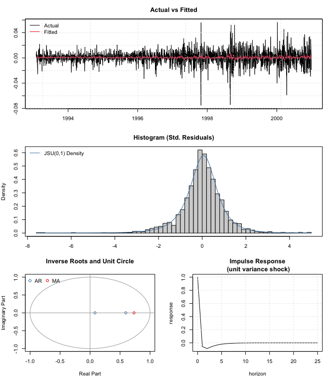

```r
plot(mod)
```

The impulse response function (`arma_irf`) of this model shows that a unit variance shock will decay to zero after about 5 periods.

### Prediction

The `predict` method will generate h step ahead predictions of the conditional mean, the model standard deviation as well as a simulated predictive distribution using either bootstrap re-sampling of the residuals else parametric sampling based on the distribution chosen to estimate the model. Optionally, the user can pass in a matrix of innovations to be used instead. These can either be uniform deviates (in effect quantiles) which will be transformed into the model’s distributional innovations, standardized innovations which will be scaled by the standard deviation of the model, else non-standardized innovations. The latter may be useful when passing a GARCH generated set of forecast innovations.

The `forc_dates` argument allows the user to pass a set of time indices representing the forecast horizon, else the function will try to auto-generate these based on the estimated sampling frequency of the data.

```r
p <- predict(mod, h = 25, bootstrap = TRUE, nsim = 5000)
head(cbind(p$mean, p$sigma))
```

```
#>                  p.mean    p.sigma
#> 2000-12-30 0.0004112512 0.01070811
#> 2000-12-31 0.0014352212 0.01072511
#> 2001-01-01 0.0011839164 0.01076498
#> 2001-01-02 0.0009644945 0.01078151
#> 2001-01-03 0.0008282762 0.01078748
#> 2001-01-04 0.0007467763 0.01078959
```

Since the output is of class `tsmodel.predict`, the corresponding plot method from the tsmethods package can be used directly.

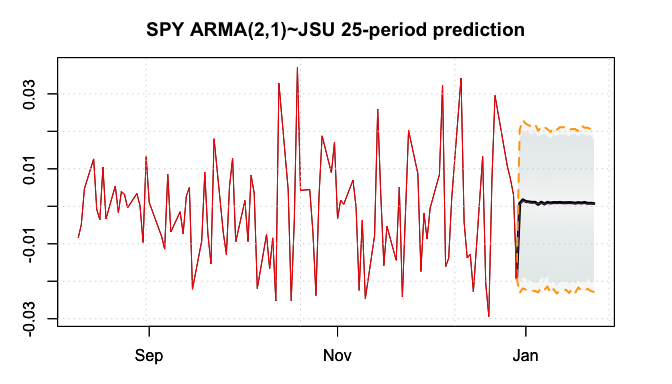

```r
par(mar = c(3,3,3,3))
plot(p, n_original = 100, main = "SPY ARMA(2,1)~JSU 25-period prediction", ylab = "", xlab = "", gradient_color = "azure3",interval_color = "orange")
```

### Filtering and Simulation

The 2 final methods of note in the package are `tsfilter` and `simulate` which allow the filtering of new data and simulation, respectively. Both of these methods can be dispatched from either an estimated model of class `tsarma.estimate` as well as a specification object of class `tsarma.spec`. In the following demonstration, the combination of `tsfilter` and `simulate` methods is illustrated.

We first take the original specification object and replace the parameter matrix holding the estimated parameters from the estimated object. This is all that is required.

```r
parmatrix <- copy(mod$parmatrix)
spec$parmatrix <- parmatrix
```

In the next step we verify that `tsfilter` both the specification and estimated objects return the same result.

```r
filter_spec <- tsfilter(spec, y = spyr[2001:2010])
filter_model <- tsfilter(mod, y = spyr[2001:2010])
all.equal(fitted(filter_spec), fitted(filter_model))
```

```
#> [1] TRUE
```

Filtering on a specification object is equivalent to running through the ARMA recursion with fixed parameters. We can check that passing a specification object without new data to `tsfilter` will results in the same values as those from the estimated model.

```r
filter_spec <- tsfilter(spec)
all.equal(fitted(mod), fitted(filter_spec))
```

```
#> [1] TRUE
```

It is also possible to completely replace y with a new dataset if we have pooled estimates of the parameters to use in the parameter matrix. Simply put, the filtering algorithm takes a set of fixed parameters and filters the data.

Next, we illustrate how to generate a predictive distribution using the `simulate` method on both the estimated and specification objects and verify replication of results with the `predict` method.

```r
sim_spec <- spec
sim_spec$parmatrix <- copy(mod$parmatrix)
filter_spec <- tsfilter(sim_spec)
maxpq <- max(spec$model$order)
series_init <- tail(sim_spec$target$y_orig, maxpq)
innov_init <- as.numeric(tail(residuals(filter_spec), maxpq))
simulate_spec <- simulate(sim_spec, nsim = 2000, seed = 100, h = 10, series_init = series_init, innov_init = innov_init)
simulate_model <- simulate(mod, nsim = 2000, seed = 100, h = 10, series_init = series_init, innov_init = innov_init)
set.seed(100)
p <- predict(mod, h = 10, nsim = 2000)
# equivalence between estimation and specification simulated distributions
all.equal(simulate_spec$simulated, simulate_model$simulated)
```

```
#> [1] TRUE
```

```r
# equivalence between simulation method and prediction method distributions
all.equal(simulate_spec$simulated, p$distribution)
```

```
#> [1] TRUE
```

## Conclusion

The **tsarma** package is currently under development and may change in the future. Potential areas for improvement are likely to be the inclusion of non-stationary series turning it into an ARIMA model. Adding seasonality is not something which is planned, and users who work with stationary seasonal series can use fourier terms in the regressors using the `fourier_series` function from tsaux.

## Appendix

Table: tsarma function map

| (...) | type | input | output |
| --- | --- | --- | --- |
| tsarma |  |  |  |
| ¦--arma_modelspec | function | xts | tsarma.spec |
| ¦ ¦--simulate | method | tsarma.spec | tsarma.simulate |
| ¦ ¦--tsfilter | method | tsarma.spec | tsarma.estimate |
| ¦ °--tsbacktest | method | tsarma.spec | list |
| ¦--estimate | method | tsarma.spec | tsarma.estimate |
| ¦ ¦--summary | method | tsarma.estimate | summary.tsarma |
| ¦ ¦ °--print | method | summary.tsarma | print/flextable |
| ¦ ¦--tidy | method | tsarma.estimate | tibble |
| ¦ ¦--glance | method | tsarma.estimate | tibble |
| ¦ ¦--plot | method | tsarma.estimate | plot |
| ¦ ¦--coef | method | tsarma.estimate | numeric |
| ¦ ¦--logLik | method | tsarma.estimate | logLik |
| ¦ ¦--fitted | method | tsarma.estimate | xts |
| ¦ ¦--residuals | method | tsarma.estimate | xts |
| ¦ ¦--tsequation | method | tsarma.estimate | list |
| ¦ ¦--AIC | method | tsarma.estimate | numeric |
| ¦ ¦--BIC | method | tsarma.estimate | numeric |
| ¦ ¦--confint | method | tsarma.estimate | matrix |
| ¦ ¦--vcov | method | tsarma.estimate | matrix |
| ¦ ¦--bread | method | tsarma.estimate | matrix |
| ¦ ¦--estfun | method | tsarma.estimate | matrix |
| ¦ ¦--predict | method | tsarma.estimate | tsmodel.predict |
| ¦ ¦ ¦--plot | method | tsmodel.predict | plot |
| ¦ ¦ °--pit | method | tsarma.predict | xts |
| ¦ ¦--simulate | method | tsarma.estimate | tsmodel.simulate |
| ¦ ¦--tsfilter | method | tsarma.estimate | tsmodel.estimate |
| ¦ ¦--unconditional | method | tsarma.estimate | numeric |
| ¦ ¦--sigma | method | tsarma.estimate | numeric |
| ¦ ¦--nobs | method | tsarma.estimate | numeric |
| ¦ ¦--pit | method | tsarma.estimate | xts |
| ¦ °--halflife | method | numeric | numeric |
| ¦--arma_irf | function | numeric | arma.irf |
| ¦ °--plot | method | arma.irf | plot |
| °--arma_roots | function | numeric | arma.roots |
| °--plot | method | arma.roots | plot |